# Practical Machine Learning

G Nugent

23 January 2015

## Introduction

The purpose of this project is to build a model using data generated from correct and incorrect weightlifting exercise methods to predict which of these methods is being carried out. The data was generated by asking 6 participants were asked to perform one set of 10 repetitions of the Unilateral Dumbbell Biceps Curl in five different fashions. One group was done in the correct fashion and the other 4 were common mistakes that can be replicated.

Read more: http://groupware.les.inf.puc-rio.br/har#ixzz3PeHcLLMP

Using this data it should be possible to build a model so that the method in which the exercise can be classified into one of the 5 classes.

## Preliminary Data Analysis

The weightlifting exercise data downloaded using the following method. This data was split into two sets prior to download. The first set contains the training data on which to build the model and the second set is a testing set for the purpose of grading the model for the coursera model.

```r
#download training data
download.file('https://d396qusza40orc.cloudfront.net/predmachlearn/pml-training.csv', 'pml-training.csv', method="curl")
#download test data
download.file('https://d396qusza40orc.cloudfront.net/predmachlearn/pml-testing.csv', 'pml-testing.csv',method="curl")
```

All the modeling and analysis has been run using the training set data.

```r
full_data <- read.csv('pml-training.csv')
dim(full_data)
```

```
## [1] 19622   160
```

This data set contains 160 variables and 19622 records, a summary of this data will help identify the variables that can be used to build the model (see appendix 1).

From the summary, there are a set of variables that have numerical data for all 19622 records and also have a meaning in terms of the data that have been collected and for any data that would be collected in the future.

Details of the experiment design there was sensors placed on the belt, dumbbell, forearm and arm. For each of these sensors the following measurements is kept along with classe which contains the exercise type:

- yaw
- roll
- pitch
- total acceleration
- magnet x
- magnet y
- magnet z
- acceleration x
- acceleration y
- acceleration z
- gyro x
- gyro y
- gyro z

Using the grep function these variables (plus the ‘classe’ variable) are kept to leave 53 variables.

```r
clean_data <- clean_data <- full_data[,grep("^(classe|gyros|accel|magnet|roll|pitch|yaw|total_accel)", names(full_data))]
```

These 53 variables were analysed to see if any of the variables have zero or near zero variance and as such would not add to the model (See appendix 2). None of these variables have to be removed under these conditions.

### Cross validation

```r
library(caret)
set.seed(1979)

inTraining <- createDataPartition(y=clean_data$classe, p=0.75, list=F)
training <- clean_data[inTraining,]
validation <- clean_data[-inTraining,]
```

The following plot is a matrix plot of the pitch, yaw, roll and total acceleration of the forearm sensor. There seems to be some separation in the the groups when looking at the roll, pitch and yaw, although it doesn’t look to be a linear relationship.

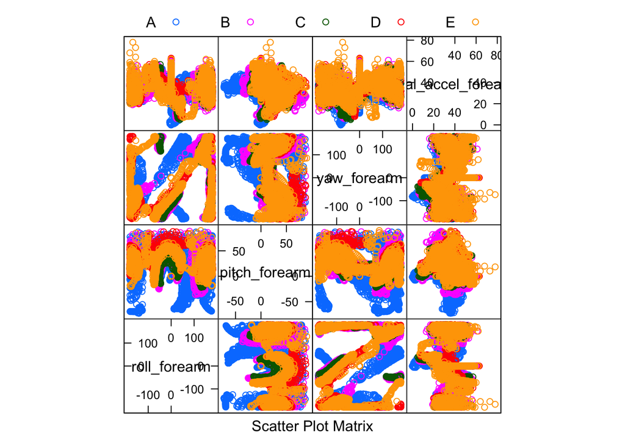

```r
featurePlot(training[,grep("forearm$",names(training))],training[,53],"pairs",auto.key = list(columns = 5))
```

Plotting (see below) the acceleration of the sensors and the magnets in the xyz planes for all of the sensors shows that is no obvious differences between the classes using these variables

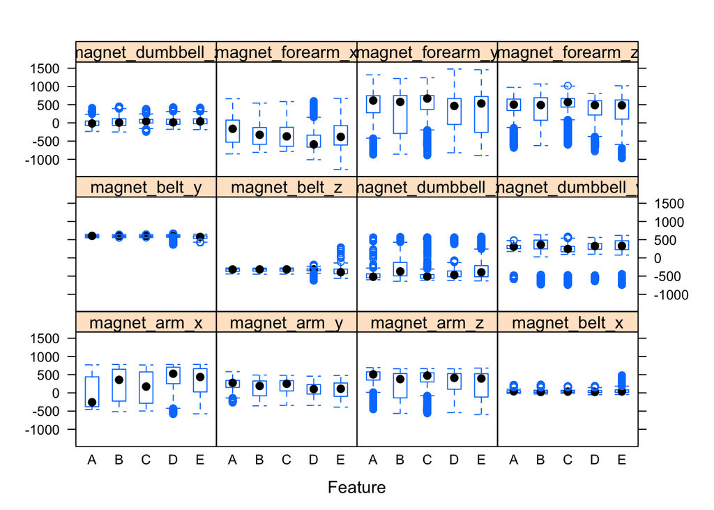

```r
featurePlot(training[,grep("^magnet",names(training))],training[,53],"box")
```

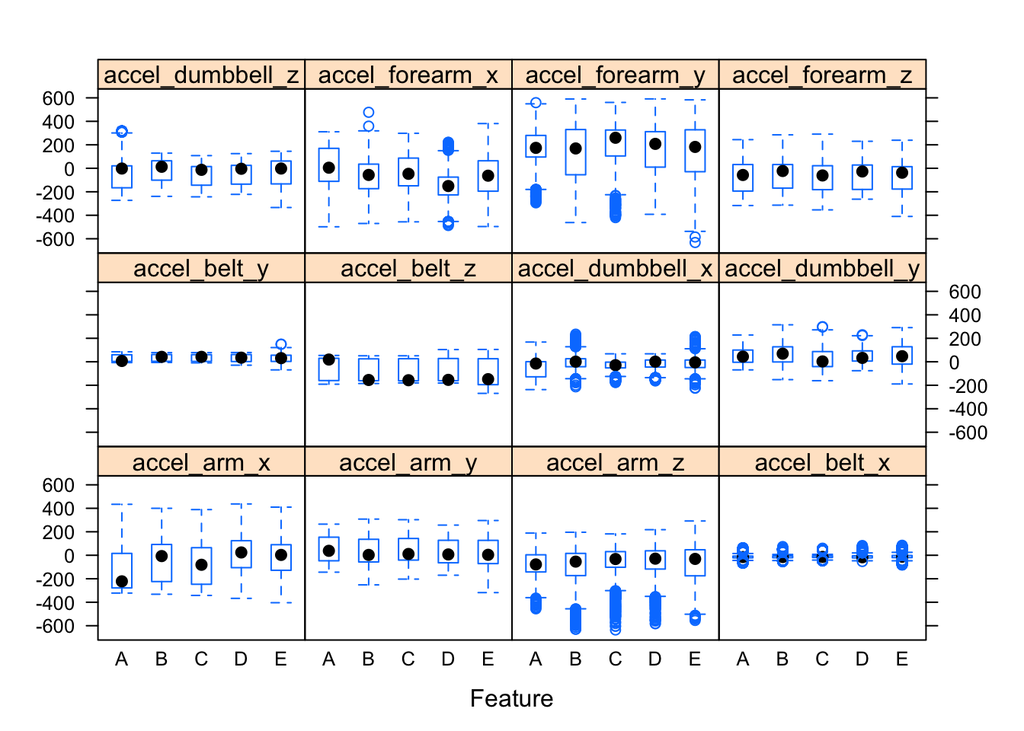

```r
featurePlot(training[,grep("^accel",names(training))],training[,53],"box")
```

## Data Modelling

For classification problems there are a number of different methods that can used to model the data. For this data set linear discrimination analysis (LDA) is not applicable due to the data in the variables chosen so far not being completely separated in a linear fashion. In some of the plots the data could be classified using the Quadratic discriminant analysis (QDA) method.

This first model is trained as follows, using a 10 fold internal cross validation.

```r
mod.qda <- train(classe ~ ., data=training, trControl = trainControl(method="cv", number=10), method="qda")
mod.qda
```

```
## Quadratic Discriminant Analysis
##
## 14718 samples
##    52 predictor
##     5 classes: 'A', 'B', 'C', 'D', 'E'
##
## No pre-processing
## Resampling: Cross-Validated (10 fold)
##
## Summary of sample sizes: 13244, 13247, 13248, 13246, 13245, 13246, ...
##
## Resampling results
##
##   Accuracy   Kappa      Accuracy SD  Kappa SD
##   0.8961115  0.8686327  0.009578241  0.01208561
##
##
```

From the internal cross validation, this model has an accuracy of 89.6%. For the held out validation set the accuracy is 89.9%.

```r
pred.qda <- predict(mod.qda, validation[,-53])
confusionMatrix(pred.qda, validation$classe)
```

```
## Confusion Matrix and Statistics
##
##           Reference
## Prediction    A    B    C    D    E
##          A 1330   73    4    3    0
##          B   42  778   45    1   23
##          C    6   79  792  106   35
##          D   11    2    9  683   18
##          E    6   17    5   11  825
##
## Overall Statistics
##
##                Accuracy : 0.8989
##                  95% CI : (0.8901, 0.9072)
##     No Information Rate : 0.2845
##     P-Value [Acc > NIR] : < 2.2e-16
##
##                   Kappa : 0.872
##  Mcnemar's Test P-Value : < 2.2e-16
##
## Statistics by Class:
##
##                      Class: A Class: B Class: C Class: D Class: E
## Sensitivity            0.9534   0.8198   0.9263   0.8495   0.9156
## Specificity            0.9772   0.9719   0.9442   0.9902   0.9903
## Pos Pred Value         0.9433   0.8751   0.7780   0.9447   0.9549
## Neg Pred Value         0.9814   0.9574   0.9838   0.9711   0.9812
## Prevalence             0.2845   0.1935   0.1743   0.1639   0.1837
## Detection Rate         0.2712   0.1586   0.1615   0.1393   0.1682
## Detection Prevalence   0.2875   0.1813   0.2076   0.1474   0.1762
## Balanced Accuracy      0.9653   0.8959   0.9352   0.9199   0.9530
```

Another method that can used in classification modelling is a nearest neighbor approach. This method works better when the variables is scaled and centered because of the variation in scales can effect the outcome.

```r
preproc <- preProcess(training[,-53], method=c("scale","center"))
proc_train <- predict(preproc, training[,-53])
proc_valid <- predict(preproc, validation[,-53])
```

Now to build a nearest neighbor model, again this model was built with a 10 fold cross validation in the predict method.

```r
mod.knn <- train(training$classe ~ ., data=proc_train, trControl = trainControl(method="cv", number=10), method="knn")
mod.knn
```

```
## k-Nearest Neighbors
##
## 14718 samples
##    51 predictor
##     5 classes: 'A', 'B', 'C', 'D', 'E'
##
## No pre-processing
## Resampling: Cross-Validated (10 fold)
##
## Summary of sample sizes: 13247, 13246, 13245, 13245, 13246, 13248, ...
##
## Resampling results across tuning parameters:
##
##   k  Accuracy   Kappa      Accuracy SD  Kappa SD
##   5  0.9652807  0.9560768  0.004841022  0.006127824
##   7  0.9531874  0.9407659  0.007337294  0.009283964
##   9  0.9415022  0.9259744  0.008305672  0.010505619
##
## Accuracy was used to select the optimal model using  the largest value.
## The final value used for the model was k = 5.
```

The using the default tuning parameters it seems that k=5 gives the best results internally. this has a accuracy of 96.5%. For the held out validation set this accuracy is 97.1%

```r
pred.knn <- predict(mod.knn, proc_valid)
confusionMatrix(pred.knn, validation$classe)
```

```
## Confusion Matrix and Statistics
##
##           Reference
## Prediction    A    B    C    D    E
##          A 1380   20    7    1    0
##          B    6  908   11    0    4
##          C    6   18  821   32   10
##          D    2    3   16  768    2
##          E    1    0    0    3  885
##
## Overall Statistics
##
##                Accuracy : 0.971
##                  95% CI : (0.966, 0.9756)
##     No Information Rate : 0.2845
##     P-Value [Acc > NIR] : < 2.2e-16
##
##                   Kappa : 0.9634
##  Mcnemar's Test P-Value : 0.0002549
##
## Statistics by Class:
##
##                      Class: A Class: B Class: C Class: D Class: E
## Sensitivity            0.9892   0.9568   0.9602   0.9552   0.9822
## Specificity            0.9920   0.9947   0.9837   0.9944   0.9990
## Pos Pred Value         0.9801   0.9774   0.9256   0.9709   0.9955
## Neg Pred Value         0.9957   0.9897   0.9915   0.9912   0.9960
## Prevalence             0.2845   0.1935   0.1743   0.1639   0.1837
## Detection Rate         0.2814   0.1852   0.1674   0.1566   0.1805
## Detection Prevalence   0.2871   0.1894   0.1809   0.1613   0.1813
## Balanced Accuracy      0.9906   0.9757   0.9720   0.9748   0.9906
```

Another way that classification can be predicted is using a tree classification method.

```r
mod.tree <- train(classe ~ ., data=training, trControl = trainControl(method="cv", number=10), method="rpart")
mod.tree
```

```
## CART
##
## 14718 samples
##    52 predictor
##     5 classes: 'A', 'B', 'C', 'D', 'E'
##
## No pre-processing
## Resampling: Cross-Validated (10 fold)
##
## Summary of sample sizes: 13247, 13248, 13246, 13245, 13244, 13245, ...
##
## Resampling results across tuning parameters:
##
##   cp          Accuracy   Kappa       Accuracy SD  Kappa SD
##   0.03598215  0.5009875  0.34777359  0.07963062   0.13028799
##   0.05965379  0.3906082  0.16614662  0.05325685   0.08941927
##   0.11487705  0.3234205  0.05978087  0.04147540   0.06348530
##
## Accuracy was used to select the optimal model using  the largest value.
## The final value used for the model was cp = 0.03598215.
```

this best method from this only gives an accuracy of 50.1% from the internal cross-validation. The external validation gives an accuracy of 49.8%

```r
pred.tree <- predict(mod.tree, validation)
confusionMatrix(pred.tree, validation$classe)
```

```
## Confusion Matrix and Statistics
##
##           Reference
## Prediction    A    B    C    D    E
##          A 1265  370  401  372  138
##          B   23  337   25  138  114
##          C  105  242  429  294  240
##          D    0    0    0    0    0
##          E    2    0    0    0  409
##
## Overall Statistics
##
##                Accuracy : 0.4976
##                  95% CI : (0.4835, 0.5116)
##     No Information Rate : 0.2845
##     P-Value [Acc > NIR] : < 2.2e-16
##
##                   Kappa : 0.3434
##  Mcnemar's Test P-Value : NA
##
## Statistics by Class:
##
##                      Class: A Class: B Class: C Class: D Class: E
## Sensitivity            0.9068  0.35511  0.50175   0.0000  0.45394
## Specificity            0.6349  0.92415  0.78242   1.0000  0.99950
## Pos Pred Value         0.4969  0.52904  0.32748      NaN  0.99513
## Neg Pred Value         0.9449  0.85657  0.88147   0.8361  0.89050
## Prevalence             0.2845  0.19352  0.17435   0.1639  0.18373
## Detection Rate         0.2580  0.06872  0.08748   0.0000  0.08340
## Detection Prevalence   0.5192  0.12989  0.26713   0.0000  0.08381
## Balanced Accuracy      0.7709  0.63963  0.64208   0.5000  0.72672
```

To improve on this poor result, the random forest method can be used, this creates a number of tree models using a random selection of the variables.

```r
mod.rf <- train(classe ~ ., data=training, trControl = trainControl(method="cv", number=10), method="rf")
mod.rf
```

```
## Random Forest
##
## 14718 samples
##    52 predictor
##     5 classes: 'A', 'B', 'C', 'D', 'E'
##
## No pre-processing
## Resampling: Cross-Validated (10 fold)
##
## Summary of sample sizes: 13246, 13247, 13245, 13245, 13247, 13247, ...
##
## Resampling results across tuning parameters:
##
##   mtry  Accuracy   Kappa      Accuracy SD  Kappa SD
##    2    0.9925261  0.9905452  0.002543180  0.003217525
##   27    0.9925934  0.9906301  0.004269903  0.005402093
##   52    0.9891280  0.9862459  0.004934755  0.006242891
##
## Accuracy was used to select the optimal model using  the largest value.
## The final value used for the model was mtry = 27.
```

In the final model the accuracy is 99.3% from the internal cross validation. When the external validation set is predicted and compared the accuracy is 99.4%

```r
pred.rf <- predict(mod.rf, validation)
confusionMatrix(pred.rf, validation$classe)
```

```
## Confusion Matrix and Statistics
##
##           Reference
## Prediction    A    B    C    D    E
##          A 1394    9    0    0    0
##          B    0  936    4    0    0
##          C    0    4  849    7    1
##          D    0    0    2  797    2
##          E    1    0    0    0  898
##
## Overall Statistics
##
##                Accuracy : 0.9939
##                  95% CI : (0.9913, 0.9959)
##     No Information Rate : 0.2845
##     P-Value [Acc > NIR] : < 2.2e-16
##
##                   Kappa : 0.9923
##  Mcnemar's Test P-Value : NA
##
## Statistics by Class:
##
##                      Class: A Class: B Class: C Class: D Class: E
## Sensitivity            0.9993   0.9863   0.9930   0.9913   0.9967
## Specificity            0.9974   0.9990   0.9970   0.9990   0.9998
## Pos Pred Value         0.9936   0.9957   0.9861   0.9950   0.9989
## Neg Pred Value         0.9997   0.9967   0.9985   0.9983   0.9993
## Prevalence             0.2845   0.1935   0.1743   0.1639   0.1837
## Detection Rate         0.2843   0.1909   0.1731   0.1625   0.1831
## Detection Prevalence   0.2861   0.1917   0.1756   0.1633   0.1833
## Balanced Accuracy      0.9984   0.9926   0.9950   0.9952   0.9982
```

## Test Data

The data for the marked test set is loaded in and the results predicted using the random forest method.

```r
test <- read.csv('pml-testing.csv')
pred.test <- predict(mod.rf, test)
```

To prepare the files for submission the predicted classes need to be converted from a factor to a character, and using a function for write these out to separate files, the answers were written to file and submitted,

```r
answers <- as.character(pred.test)

pml_write_files = function(x){
  n = length(x)
  for(i in 1:n){
    filename = paste0("problem_id_",i,".txt")
    write.table(x[i],file=filename,quote=FALSE,row.names=FALSE,col.names=FALSE)
  }
}

pml_write_files(answers)
```

## Conclusions

In conclusion the class of exercise was predicted using different models and their errors where compared using both an internal cross validation and validation set excluded from training set. from the four models evaluated the random forest method performed the best with an accuracy of >99%. The neighest neighbor model where k = 5 also performed well with an accuracy of >96%.

## Appendix 1

summary of full data

```r
summary(full_data)
```

```
##        X            user_name    raw_timestamp_part_1 raw_timestamp_part_2
##  Min.   :    1   adelmo  :3892   Min.   :1.322e+09    Min.   :   294
##  1st Qu.: 4906   carlitos:3112   1st Qu.:1.323e+09    1st Qu.:252912
##  Median : 9812   charles :3536   Median :1.323e+09    Median :496380
##  Mean   : 9812   eurico  :3070   Mean   :1.323e+09    Mean   :500656
##  3rd Qu.:14717   jeremy  :3402   3rd Qu.:1.323e+09    3rd Qu.:751891
##  Max.   :19622   pedro   :2610   Max.   :1.323e+09    Max.   :998801
##
##           cvtd_timestamp  new_window    num_window      roll_belt
##  28/11/2011 14:14: 1498   no :19216   Min.   :  1.0   Min.   :-28.90
##  05/12/2011 11:24: 1497   yes:  406   1st Qu.:222.0   1st Qu.:  1.10
##  30/11/2011 17:11: 1440               Median :424.0   Median :113.00
##  05/12/2011 11:25: 1425               Mean   :430.6   Mean   : 64.41
##  02/12/2011 14:57: 1380               3rd Qu.:644.0   3rd Qu.:123.00
##  02/12/2011 13:34: 1375               Max.   :864.0   Max.   :162.00
##  (Other)         :11007
##    pitch_belt          yaw_belt       total_accel_belt kurtosis_roll_belt
##  Min.   :-55.8000   Min.   :-180.00   Min.   : 0.00             :19216
##  1st Qu.:  1.7600   1st Qu.: -88.30   1st Qu.: 3.00    #DIV/0!  :   10
##  Median :  5.2800   Median : -13.00   Median :17.00    -1.908453:    2
##  Mean   :  0.3053   Mean   : -11.21   Mean   :11.31    -0.016850:    1
##  3rd Qu.: 14.9000   3rd Qu.:  12.90   3rd Qu.:18.00    -0.021024:    1
##  Max.   : 60.3000   Max.   : 179.00   Max.   :29.00    -0.025513:    1
##                                                        (Other)  :  391
##  kurtosis_picth_belt kurtosis_yaw_belt skewness_roll_belt
##           :19216            :19216              :19216
##  #DIV/0!  :   32     #DIV/0!:  406     #DIV/0!  :    9
##  47.000000:    4                       0.000000 :    4
##  -0.150950:    3                       0.422463 :    2
##  -0.684748:    3                       -0.003095:    1
##  -1.750749:    3                       -0.010002:    1
##  (Other)  :  361                       (Other)  :  389
##  skewness_roll_belt.1 skewness_yaw_belt max_roll_belt     max_picth_belt
##           :19216             :19216     Min.   :-94.300   Min.   : 3.00
##  #DIV/0!  :   32      #DIV/0!:  406     1st Qu.:-88.000   1st Qu.: 5.00
##  0.000000 :    4                        Median : -5.100   Median :18.00
##  -2.156553:    3                        Mean   : -6.667   Mean   :12.92
##  -3.072669:    3                        3rd Qu.: 18.500   3rd Qu.:19.00
##  -6.324555:    3                        Max.   :180.000   Max.   :30.00
##  (Other)  :  361                        NA's   :19216     NA's   :19216
```

[output cut: 313 more lines]

```
##  Min.   :-446.00   Min.   :-1280.0   Min.   :-896.0   Min.   :-973.0
##  1st Qu.:-182.00   1st Qu.: -616.0   1st Qu.:   2.0   1st Qu.: 191.0
##  Median : -39.00   Median : -378.0   Median : 591.0   Median : 511.0
##  Mean   : -55.29   Mean   : -312.6   Mean   : 380.1   Mean   : 393.6
##  3rd Qu.:  26.00   3rd Qu.:  -73.0   3rd Qu.: 737.0   3rd Qu.: 653.0
##  Max.   : 291.00   Max.   :  672.0   Max.   :1480.0   Max.   :1090.0
##
##  classe
##  A:5580
##  B:3797
##  C:3422
##  D:3216
##  E:3607
##
##
```

## Appendix 2

Results of near zero variance analysis

```r
nearZeroVar(clean_data, saveMetrics = TRUE)
```

```
##                      freqRatio percentUnique zeroVar   nzv
## roll_belt             1.101904     6.7781062   FALSE FALSE
## pitch_belt            1.036082     9.3772296   FALSE FALSE
## yaw_belt              1.058480     9.9734991   FALSE FALSE
## total_accel_belt      1.063160     0.1477933   FALSE FALSE
## gyros_belt_x          1.058651     0.7134849   FALSE FALSE
## gyros_belt_y          1.144000     0.3516461   FALSE FALSE
## gyros_belt_z          1.066214     0.8612782   FALSE FALSE
## accel_belt_x          1.055412     0.8357966   FALSE FALSE
## accel_belt_y          1.113725     0.7287738   FALSE FALSE
## accel_belt_z          1.078767     1.5237998   FALSE FALSE
## magnet_belt_x         1.090141     1.6664968   FALSE FALSE
## magnet_belt_y         1.099688     1.5187035   FALSE FALSE
## magnet_belt_z         1.006369     2.3290184   FALSE FALSE
## roll_arm             52.338462    13.5256345   FALSE FALSE
## pitch_arm            87.256410    15.7323412   FALSE FALSE
## yaw_arm              33.029126    14.6570176   FALSE FALSE
## total_accel_arm       1.024526     0.3363572   FALSE FALSE
## gyros_arm_x           1.015504     3.2769341   FALSE FALSE
## gyros_arm_y           1.454369     1.9162165   FALSE FALSE
## gyros_arm_z           1.110687     1.2638875   FALSE FALSE
## accel_arm_x           1.017341     3.9598410   FALSE FALSE
## accel_arm_y           1.140187     2.7367241   FALSE FALSE
## accel_arm_z           1.128000     4.0362858   FALSE FALSE
## magnet_arm_x          1.000000     6.8239731   FALSE FALSE
## magnet_arm_y          1.056818     4.4439914   FALSE FALSE
## magnet_arm_z          1.036364     6.4468454   FALSE FALSE
## roll_dumbbell         1.022388    84.2065029   FALSE FALSE
## pitch_dumbbell        2.277372    81.7449801   FALSE FALSE
## yaw_dumbbell          1.132231    83.4828254   FALSE FALSE
## total_accel_dumbbell  1.072634     0.2191418   FALSE FALSE
## gyros_dumbbell_x      1.003268     1.2282132   FALSE FALSE
## gyros_dumbbell_y      1.264957     1.4167771   FALSE FALSE
## gyros_dumbbell_z      1.060100     1.0498420   FALSE FALSE
## accel_dumbbell_x      1.018018     2.1659362   FALSE FALSE
## accel_dumbbell_y      1.053061     2.3748853   FALSE FALSE
## accel_dumbbell_z      1.133333     2.0894914   FALSE FALSE
## magnet_dumbbell_x     1.098266     5.7486495   FALSE FALSE
## magnet_dumbbell_y     1.197740     4.3012945   FALSE FALSE
## magnet_dumbbell_z     1.020833     3.4451126   FALSE FALSE
## roll_forearm         11.589286    11.0895933   FALSE FALSE
## pitch_forearm        65.983051    14.8557741   FALSE FALSE
## yaw_forearm          15.322835    10.1467740   FALSE FALSE
## total_accel_forearm   1.128928     0.3567424   FALSE FALSE
## gyros_forearm_x       1.059273     1.5187035   FALSE FALSE
## gyros_forearm_y       1.036554     3.7763735   FALSE FALSE
## gyros_forearm_z       1.122917     1.5645704   FALSE FALSE
## accel_forearm_x       1.126437     4.0464784   FALSE FALSE
## accel_forearm_y       1.059406     5.1116094   FALSE FALSE
## accel_forearm_z       1.006250     2.9558659   FALSE FALSE
## magnet_forearm_x      1.012346     7.7667924   FALSE FALSE
## magnet_forearm_y      1.246914     9.5403119   FALSE FALSE
## magnet_forearm_z      1.000000     8.5771073   FALSE FALSE
## classe                1.469581     0.0254816   FALSE FALSE
```